# Examining the relationship between the big-5 personality facets and implicit racial attitudes

Analysis

Template: Ian Hussey, content: Emilie

2024-01-14

# Dependencies

```r
library(tidyverse)
library(knitr)
library(kableExtra)
library(janitor)
library(scales)
library(psych) #For Cronbachs Alpha
library(report) #For report in Hypothesis Testing
library(patchwork) #For combining plots
library(cowplot) #For combinint plots
library(ggplot2) #For plots
```

# Data

Load the processed data and apply the global exclusions.

```r
data_processed <- read_csv("../data/processed/data_processed.csv")

#Only keep the participants flagged with 'include'.
data_processed_after_exclusions <- data_processed |>
  filter(exclude_participant == "include")
```

# Sample descriptives

## Sample size before exclusions

```r
data_processed |>
  distinct(unique_id) |>
  count(name = "n") |>
  kable() |>
  add_header_above(header = c( "Sample before exclusions" = 1)) |>
  kable_classic(full_width = FALSE)
```

| Sample before exclusions n |
| --- |
| 1932 |

## Sample size after exclusions

Sample used in subsequent analyses.

```r
data_processed_after_exclusions |>
  count(name = "n") |>
  kable() |>
  add_header_above(header = c("For analysis" = 1)) |>
  kable_classic(full_width = FALSE)
```

| For analysis n |
| --- |
| 164 |

## Demographic Summary: Age

Mean value of age and the standard deviation thereof are listed. As demographic information was given voluntarily, the percentage of respondents who did not provide this information is listed additionally.

```r
data_processed_after_exclusions |>
  mutate(age = as.numeric(age)) |>
  summarise(Mean = mean(age, na.rm = TRUE),
            SD = sd(age, na.rm = TRUE)) |>
  mutate_all(.funs = janitor::round_half_up, digits = 1) |>
  kable(align = "lccc") |>
  add_header_above(header = c("Age" = 2)) |>
  kable_classic(full_width = FALSE)
```

| Age Mean | Age SD |
| --- | --- |
| 30.6 | 11.2 |

```r
#Percentage of provided information

data_processed_after_exclusions |>
  summarise(Total_Participants = n(),
            Age_available = sum(!is.na(as.numeric(age))),
            Percentage_Age_available = paste0(
              janitor::round_half_up((Age_available / Total_Participants) * 100, digits = 1), "%"),
            Age_not_available = Total_Participants - Age_available,
            Percentage_Age_not_available = paste0(
              janitor::round_half_up((Age_not_available / Total_Participants) * 100, digits = 1), "%")) |>
  select(-Total_Participants) |>
  kable(align= "lccc") |> #locate the numbers in the middle as the percentage calculation puts them left which messes up the overall appearance
  add_header_above(header = c("Age" = 4)) |>
  kable_classic(full_width = FALSE)
```

| Age Age_available | Age Percentage_Age_available | Age Age_not_available | Age Percentage_Age_not_available |
| --- | --- | --- | --- |
| 141 | 86% | 23 | 14% |

## Demographic summary: Gender

The total number and percentage of participants categorized as female, male and “other/missing/missing” are calculated.

```r
demographics_gender <- data_processed_after_exclusions |>
  select(gender) |>
  na.omit(T) |>
  tabyl(gender) |>
  adorn_pct_formatting(digits = 2)

#Calculation using the same format as above, without assigning a new variable

data_processed_after_exclusions |>
  rename(Gender = gender) |>
  group_by(Gender) |>
  summarise(n = n()) |>
  mutate(Percent = paste0(round_half_up((n / sum(n)) * 100, 1), "%")) |>
  kable(align = "lccc") |>
  kable_classic(full_width = FALSE)
```

| Gender | n | Percent |
| --- | --- | --- |
| f | 87 | 53% |
| m | 54 | 32.9% |
| other/missing/error | 23 | 14% |

## Demographic summary: Available information

Percentage and total number are calculated according to the participants who provided both demographic information, i.e. age and gender.

```r
data_processed_after_exclusions |>
  rename(Gender = gender) |>
  filter(!(Gender %in% c("other/missing/error"))) |> #as this variable indicates no information it is filtered out
  group_by(Gender, age) |>
  summarise(n = n()) |>
  summarise( Total_Participants = sum(n),
             Gender_and_Age_available = sum(n > 0),
             Percentage_Both_Available =paste0(janitor::round_half_up((Gender_and_Age_available / Total_Participants) * 100, digits =1), "%")) |>
  mutate_at(c("Total_Participants", "Gender_and_Age_available"),
            .funs = janitor::round_half_up, digits = 2) |>
  kable(align = "lccc") |>
  add_header_above(header = c("Percentage of Participants with Age and Gender Demographics" = 4)) |>
  kable_classic(full_width = FALSE)
```

| Percentage of Participants with Age and Gender Demographics Gender | Percentage of Participants with Age and Gender Demographics Total_Participants | Percentage of Participants with Age and Gender Demographics Gender_and_Age_available | Percentage of Participants with Age and Gender Demographics Percentage_Both_Available |
| --- | --- | --- | --- |
| f | 87 | 35 | 40.2% |
| m | 54 | 28 | 51.9% |

# BFI

## Cronbachs Alpha

Cronbach’s alpha is calculated for each BFI subscale. This parameter is an important value to calculate as it provides an indication of the so-called internal consistency of a questionnaire. It indicates the extent to which each subscale with its group of items captures the underlying latent construct, i.e. how well the BFI subscale depicts the respective trait. Therefore, Cronbach’s alpha serves an important role in the assessment of the reliability of tests, as it provides information about the accuracy of a measurement.

### Extroversion

```r
cronbach_alpha_extroversion <- data_processed_after_exclusions |>
  select(contains("bfi_e")) |>
  psych::alpha() #specify psych

print(cronbach_alpha_extroversion)
```

```
##
## Reliability analysis
## Call: psych::alpha(x = select(data_processed_after_exclusions, contains("bfi_e")))
##
##   raw_alpha std.alpha G6(smc) average_r S/N   ase mean   sd median_r
##       0.81      0.81    0.82      0.34 4.2 0.022  3.8 0.86     0.36
##
##     95% confidence boundaries
##          lower alpha upper
## Feldt     0.76  0.81  0.85
## Duhachek  0.77  0.81  0.85
##
##  Reliability if an item is dropped:
##        raw_alpha std.alpha G6(smc) average_r S/N alpha se var.r med.r
## bfi_e1      0.76      0.76    0.78      0.31 3.2    0.028 0.024  0.34
## bfi_e2      0.80      0.79    0.80      0.35 3.8    0.024 0.020  0.35
## bfi_e3      0.81      0.81    0.81      0.37 4.1    0.022 0.021  0.37
## bfi_e4      0.80      0.80    0.80      0.36 4.0    0.023 0.023  0.36
## bfi_e5      0.75      0.75    0.76      0.30 3.0    0.029 0.021  0.34
## bfi_e6      0.80      0.80    0.81      0.36 3.9    0.023 0.028  0.37
## bfi_e7      0.80      0.80    0.81      0.36 3.9    0.024 0.021  0.35
## bfi_e8      0.78      0.77    0.80      0.33 3.4    0.026 0.028  0.35
##
##  Item statistics
##         n raw.r std.r r.cor r.drop mean  sd
## bfi_e1 78  0.78  0.78  0.75   0.68  4.2 1.4
## bfi_e2 78  0.61  0.61  0.54   0.47  3.2 1.3
## bfi_e3 78  0.52  0.54  0.45   0.37  4.1 1.2
## bfi_e4 77  0.55  0.58  0.51   0.43  4.5 1.1
## bfi_e5 78  0.82  0.82  0.82   0.74  3.2 1.3
## bfi_e6 78  0.59  0.59  0.50   0.44  4.5 1.4
## bfi_e7 78  0.61  0.59  0.52   0.46  2.9 1.3
## bfi_e8 78  0.72  0.71  0.66   0.60  4.3 1.3
##
## Non missing response frequency for each item
##           1    2    3    4    5    6 miss
## bfi_e1 0.03 0.12 0.15 0.26 0.19 0.26 0.52
## bfi_e2 0.09 0.18 0.42 0.13 0.12 0.06 0.52
## bfi_e3 0.03 0.09 0.21 0.23 0.36 0.09 0.52
## bfi_e4 0.03 0.03 0.10 0.23 0.48 0.13 0.53
## bfi_e5 0.12 0.18 0.37 0.14 0.14 0.05 0.52
## bfi_e6 0.05 0.05 0.09 0.23 0.35 0.23 0.52
## bfi_e7 0.12 0.32 0.35 0.08 0.08 0.06 0.52
## bfi_e8 0.05 0.04 0.17 0.24 0.31 0.19 0.52
```

*Interpretation*: Cronbach’s alpha for extroversion equals 0.81. The value can be obtained under ‘raw_alpha’. Although an alpha of over 0.8 is considered good, it is important to note that no standardized values for assessing alpha have been established. Therefore, values of 0.8 are occasionally described as merely acceptable or even very good. By comparing the items individually, it can be concluded that they all show comparable alpha values, with item bfi_e5 having the lowest and item bfi_e3 showing the highest alpha. However, as all of them are situated in a similar range, it seems that a more detailed analysis of the items is superfluous. Furthermore, the confidence interval can provide information about the quality of alpha, whereby the lower value of 0.76 still indicates a rather high overall value.

### Conscientiousness

```r
cronbach_alpha_conscient <- data_processed_after_exclusions |>
 select(contains("bfi_c"))|>
  psych::alpha()

print(cronbach_alpha_conscient)
```

```
##
## Reliability analysis
## Call: psych::alpha(x = select(data_processed_after_exclusions, contains("bfi_c")))
##
##   raw_alpha std.alpha G6(smc) average_r S/N   ase mean  sd median_r
##        0.8      0.81    0.83      0.32 4.2 0.023  4.3 0.8     0.32
##
##     95% confidence boundaries
##          lower alpha upper
## Feldt     0.75   0.8  0.84
## Duhachek  0.75   0.8  0.84
##
##  Reliability if an item is dropped:
##        raw_alpha std.alpha G6(smc) average_r S/N alpha se var.r med.r
## bfi_c1      0.79      0.80    0.80      0.33 3.9    0.024 0.012  0.32
## bfi_c2      0.77      0.78    0.79      0.31 3.6    0.027 0.016  0.31
## bfi_c3      0.77      0.77    0.78      0.30 3.4    0.027 0.012  0.29
## bfi_c4      0.79      0.80    0.81      0.33 4.0    0.025 0.016  0.34
## bfi_c5      0.79      0.80    0.81      0.33 4.0    0.025 0.016  0.33
## bfi_c6      0.77      0.78    0.79      0.30 3.5    0.027 0.016  0.28
## bfi_c7      0.78      0.79    0.80      0.32 3.7    0.026 0.018  0.31
## bfi_c8      0.79      0.80    0.82      0.33 4.0    0.024 0.016  0.33
## bfi_c9      0.78      0.79    0.81      0.33 3.9    0.026 0.017  0.33
##
##  Item statistics
##         n raw.r std.r r.cor r.drop mean   sd
## bfi_c1 78  0.52  0.58  0.53   0.41  5.1 0.96
## bfi_c2 78  0.72  0.66  0.63   0.58  3.9 1.58
## bfi_c3 78  0.70  0.75  0.75   0.62  5.2 0.98
## bfi_c4 78  0.60  0.56  0.48   0.44  3.5 1.50
## bfi_c5 78  0.61  0.57  0.49   0.45  3.8 1.54
## bfi_c6 78  0.71  0.72  0.69   0.60  4.8 1.26
## bfi_c7 77  0.62  0.65  0.58   0.51  4.7 1.19
## bfi_c8 78  0.52  0.57  0.48   0.41  4.9 0.99
## bfi_c9 77  0.63  0.60  0.53   0.49  3.3 1.39
##
## Non missing response frequency for each item
##           1    2    3    4    5    6 miss
## bfi_c1 0.00 0.03 0.03 0.19 0.37 0.38 0.52
## bfi_c2 0.08 0.17 0.18 0.13 0.28 0.17 0.52
## bfi_c3 0.00 0.01 0.05 0.15 0.27 0.51 0.52
## bfi_c4 0.05 0.21 0.40 0.08 0.09 0.18 0.52
## bfi_c5 0.06 0.14 0.27 0.14 0.19 0.19 0.52
## bfi_c6 0.01 0.05 0.10 0.19 0.28 0.36 0.52
## bfi_c7 0.01 0.06 0.06 0.19 0.42 0.25 0.53
## bfi_c8 0.00 0.04 0.03 0.24 0.41 0.28 0.52
## bfi_c9 0.10 0.19 0.26 0.18 0.22 0.04 0.53
```

*interpretation*: The rounded alpha score of 0.8 indicates a sound value in this category again. The items correlate closely with each other, so that a conclusion about the construct of conscientiousness appears justifiable within subsequent analysis. Nevertheless, it must be emphasized that individual items perform lower compared to others. In particular, bfi_c1 and bfi_c8 show a significantly lower alpha value relative to the other items. It could therefore be advisable to examine these items further, regardless of the overall alpha value.

### Neuroticism

```r
cronbach_alpha_neuroticism <- data_processed_after_exclusions |>
  select(contains("bfi_n")) |>
  psych::alpha()

print(cronbach_alpha_neuroticism)
```

```
##
## Reliability analysis
## Call: psych::alpha(x = select(data_processed_after_exclusions, contains("bfi_n")))
##
##   raw_alpha std.alpha G6(smc) average_r S/N   ase mean   sd median_r
##       0.79      0.79    0.79      0.32 3.7 0.025  3.1 0.84     0.34
##
##     95% confidence boundaries
##          lower alpha upper
## Feldt     0.73  0.79  0.83
## Duhachek  0.74  0.79  0.84
##
##  Reliability if an item is dropped:
##        raw_alpha std.alpha G6(smc) average_r S/N alpha se var.r med.r
## bfi_n1      0.76      0.76    0.76      0.31 3.1    0.029 0.019  0.31
## bfi_n2      0.75      0.75    0.75      0.30 3.1    0.029 0.016  0.31
## bfi_n3      0.77      0.77    0.77      0.32 3.3    0.028 0.016  0.36
## bfi_n4      0.74      0.74    0.74      0.29 2.9    0.031 0.014  0.29
## bfi_n5      0.76      0.77    0.77      0.32 3.3    0.028 0.020  0.35
## bfi_n6      0.80      0.80    0.80      0.37 4.1    0.023 0.010  0.37
## bfi_n7      0.76      0.76    0.75      0.31 3.2    0.028 0.017  0.35
## bfi_n8      0.75      0.75    0.76      0.30 3.1    0.029 0.018  0.31
##
##  Item statistics
##         n raw.r std.r r.cor r.drop mean  sd
## bfi_n1 78  0.67  0.66  0.59   0.53  2.8 1.4
## bfi_n2 78  0.67  0.69  0.64   0.55  2.7 1.2
## bfi_n3 78  0.61  0.61  0.54   0.48  4.1 1.2
## bfi_n4 78  0.75  0.74  0.72   0.62  3.6 1.5
## bfi_n5 78  0.62  0.63  0.55   0.49  2.3 1.3
## bfi_n6 78  0.42  0.42  0.26   0.23  3.8 1.4
## bfi_n7 78  0.63  0.64  0.59   0.50  2.3 1.2
## bfi_n8 78  0.69  0.68  0.62   0.56  3.4 1.4
##
## Non missing response frequency for each item
##           1    2    3    4    5    6 miss
## bfi_n1 0.22 0.31 0.13 0.24 0.05 0.05 0.52
## bfi_n2 0.15 0.32 0.32 0.10 0.08 0.03 0.52
## bfi_n3 0.04 0.06 0.14 0.40 0.28 0.08 0.52
## bfi_n4 0.12 0.18 0.12 0.31 0.17 0.12 0.52
## bfi_n5 0.28 0.41 0.13 0.13 0.01 0.04 0.52
## bfi_n6 0.06 0.18 0.05 0.42 0.18 0.10 0.52
## bfi_n7 0.28 0.40 0.15 0.09 0.06 0.01 0.52
## bfi_n8 0.10 0.18 0.22 0.29 0.14 0.06 0.52
```

*Interpretation*: The Cronbachs alpha of 0.79 can be classified as acceptable to good. Except for one item, the eight items show a similarly high alpha and the lower limit within the confidence interval of 0.73 can also be considered acceptable. Nevertheless, item bfi_n6 appears to have a considerably lower value compared to the other items. Again, it might be advisable to check the item further in order to identify a reason behind this.

### Agreeableness

```r
cronbach_alpha_agreeable <- data_processed_after_exclusions |>
  select(contains("bfi_a")) |>
  psych::alpha()

print(cronbach_alpha_agreeable)
```

```
##
## Reliability analysis
## Call: psych::alpha(x = select(data_processed_after_exclusions, contains("bfi_a")))
##
##   raw_alpha std.alpha G6(smc) average_r S/N   ase mean   sd median_r
##       0.78      0.79    0.82       0.3 3.9 0.026  4.4 0.77      0.3
##
##     95% confidence boundaries
##          lower alpha upper
## Feldt     0.73  0.78  0.83
## Duhachek  0.73  0.78  0.83
##
##  Reliability if an item is dropped:
##        raw_alpha std.alpha G6(smc) average_r S/N alpha se var.r med.r
## bfi_a1      0.76      0.77    0.80      0.30 3.4    0.029 0.016  0.30
## bfi_a2      0.76      0.78    0.79      0.30 3.5    0.028 0.016  0.32
## bfi_a3      0.77      0.78    0.80      0.31 3.6    0.028 0.017  0.31
## bfi_a4      0.75      0.77    0.78      0.29 3.3    0.030 0.016  0.29
## bfi_a5      0.77      0.79    0.80      0.32 3.7    0.027 0.013  0.31
## bfi_a6      0.78      0.79    0.81      0.32 3.7    0.026 0.015  0.33
## bfi_a7      0.74      0.75    0.76      0.27 3.0    0.031 0.014  0.26
## bfi_a8      0.77      0.78    0.80      0.31 3.6    0.028 0.018  0.31
## bfi_a9      0.75      0.77    0.78      0.29 3.3    0.029 0.016  0.28
##
##  Item statistics
##         n raw.r std.r r.cor r.drop mean   sd
## bfi_a1 86  0.63  0.62  0.56   0.49  3.4 1.38
## bfi_a2 86  0.56  0.61  0.55   0.46  4.7 0.95
## bfi_a3 86  0.58  0.57  0.49   0.42  4.6 1.37
## bfi_a4 86  0.68  0.67  0.63   0.56  4.7 1.28
## bfi_a5 86  0.54  0.53  0.45   0.37  4.7 1.36
## bfi_a6 86  0.55  0.53  0.44   0.37  4.0 1.52
## bfi_a7 86  0.76  0.77  0.76   0.67  4.8 1.09
## bfi_a8 86  0.59  0.57  0.50   0.44  3.7 1.41
## bfi_a9 86  0.64  0.67  0.63   0.54  4.9 1.02
##
## Non missing response frequency for each item
##           1    2    3    4    5    6 miss
## bfi_a1 0.07 0.20 0.30 0.16 0.20 0.07 0.48
## bfi_a2 0.00 0.01 0.07 0.34 0.34 0.24 0.48
## bfi_a3 0.03 0.05 0.14 0.19 0.28 0.31 0.48
## bfi_a4 0.02 0.06 0.08 0.22 0.31 0.30 0.48
## bfi_a5 0.03 0.07 0.07 0.17 0.34 0.31 0.48
## bfi_a6 0.05 0.13 0.27 0.13 0.21 0.22 0.48
## bfi_a7 0.01 0.02 0.07 0.21 0.37 0.31 0.48
## bfi_a8 0.06 0.15 0.29 0.19 0.20 0.12 0.48
## bfi_a9 0.00 0.03 0.05 0.20 0.40 0.33 0.48
```

*Interpretation*: Similarly, the alpha of 0.78 can be classified as acceptable to good. Item bfi_a7 appears to perform slightly better than the others, but all other items appear to have similarly good inter-item correlations. The lower confidence interval of 0.73 likewise shows an acceptable value.

### Openness

```r
cronbach_alpha_openness <- data_processed_after_exclusions |>
  select(contains("bfi_o")) |>
  psych::alpha()

print(cronbach_alpha_openness)
```

```
##
## Reliability analysis
## Call: psych::alpha(x = select(data_processed_after_exclusions, contains("bfi_o")))
##
##   raw_alpha std.alpha G6(smc) average_r S/N   ase mean   sd median_r
##       0.81      0.82    0.86      0.31 4.5 0.022  4.6 0.74     0.31
##
##     95% confidence boundaries
##          lower alpha upper
## Feldt     0.76  0.81  0.85
## Duhachek  0.77  0.81  0.85
##
##  Reliability if an item is dropped:
##         raw_alpha std.alpha G6(smc) average_r S/N alpha se var.r med.r
## bfi_o1       0.77      0.78    0.83      0.29 3.6    0.027 0.023  0.25
## bfi_o10      0.80      0.81    0.84      0.33 4.4    0.023 0.022  0.31
## bfi_o2       0.80      0.81    0.86      0.32 4.3    0.024 0.032  0.34
## bfi_o3       0.80      0.80    0.84      0.31 4.1    0.024 0.026  0.31
## bfi_o4       0.79      0.80    0.85      0.31 4.0    0.025 0.031  0.25
## bfi_o5       0.77      0.79    0.83      0.29 3.7    0.026 0.023  0.27
## bfi_o6       0.80      0.81    0.85      0.32 4.2    0.024 0.029  0.31
## bfi_o7       0.81      0.82    0.85      0.33 4.4    0.022 0.026  0.32
## bfi_o8       0.80      0.81    0.84      0.32 4.1    0.024 0.027  0.31
## bfi_o9       0.79      0.80    0.84      0.31 4.1    0.025 0.026  0.29
##
##  Item statistics
##          n raw.r std.r r.cor r.drop mean   sd
## bfi_o1  86  0.76  0.76  0.76   0.68  4.6 1.12
## bfi_o10 86  0.58  0.53  0.49   0.43  3.9 1.46
## bfi_o2  86  0.51  0.55  0.46   0.42  5.5 0.84
## bfi_o3  86  0.59  0.62  0.57   0.47  4.6 1.13
## bfi_o4  86  0.67  0.66  0.60   0.56  4.9 1.17
## bfi_o5  86  0.74  0.75  0.75   0.66  4.5 1.21
## bfi_o6  86  0.58  0.57  0.51   0.46  4.7 1.24
## bfi_o7  86  0.50  0.52  0.44   0.35  4.0 1.37
## bfi_o8  86  0.56  0.60  0.55   0.47  5.0 0.89
## bfi_o9  86  0.66  0.61  0.58   0.52  4.3 1.54
##
## Non missing response frequency for each item
##            1    2    3    4    5    6 miss
## bfi_o1  0.01 0.03 0.10 0.28 0.35 0.22 0.48
## bfi_o10 0.09 0.09 0.15 0.22 0.34 0.10 0.48
## bfi_o2  0.01 0.00 0.00 0.10 0.27 0.62 0.48
## bfi_o3  0.02 0.02 0.05 0.36 0.29 0.26 0.48
## bfi_o4  0.02 0.01 0.09 0.13 0.36 0.38 0.48
## bfi_o5  0.03 0.03 0.07 0.30 0.34 0.22 0.48
## bfi_o6  0.02 0.03 0.08 0.26 0.28 0.33 0.48
## bfi_o7  0.02 0.12 0.26 0.21 0.22 0.17 0.48
## bfi_o8  0.00 0.00 0.05 0.24 0.36 0.35 0.48
## bfi_o9  0.07 0.07 0.16 0.16 0.26 0.28 0.48
```

*Interpretation*: Both Cronbach’s alpha of 0.81 and a lower confidence interval value of 0.76 can be regarded as acceptable and/or good.

# Descriptive Plots

## BFI Distribution Histograms

A series of histograms illustrates the distribution of the average values across the BFI subscales. Participants rated each item on a scale from 1 to 6.

### Extroversion

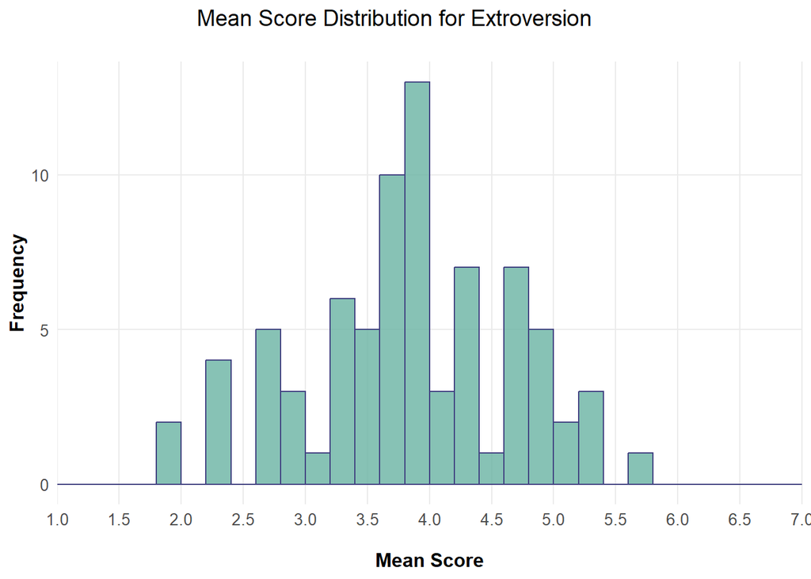

```r
ggplot(data_processed_after_exclusions, aes(x = mean_extroversion)) +
  geom_histogram(binwidth = 0.2,
                 boundary = 0,
                 fill = "#69b3a2",  #Filling color
                 color = "#404080",  # Border color
                 alpha = 0.8) + # Added transparency in order to make the plot look a bit cleaner
  xlab("Mean Score") +
  ylab("Frequency") +
  theme_minimal() +
  scale_x_continuous(breaks = seq(1, 7, 0.5), #Location of thick marks specified: Code creates breaks every 0.5 increments
                     limits = c(1, 7), expand = c(0, 0)) +  # X-Axis is limited to a range of 1 to 7 (only                                                               values within  this range are shown).Limits =                                                               0 means x is shown as specified
  coord_cartesian(xlim = c(1, 7)) + #zoom in to the important datapoints
  theme(panel.grid.minor = element_blank(),
        axis.title.x = element_text(size = 12, face = "bold", margin = margin(t=15)), #Adjust x title as it is very close to the scale
        axis.title.y = element_text(size = 12, face = "bold"), #y axis is set to the same opstics as x
        axis.text = element_text(size = 10),  # Axis text
        legend.position = "none") + #remove the legend
  ggtitle("Mean Score Distribution for Extroversion") +  # Add a title
  theme(plot.title = element_text(hjust = 0.4, size = 14, margin = margin(b = 20))) #Depending of the distribution the title looks a bit better with hjust 0.4 or 0.5
```

### Conscientiousness

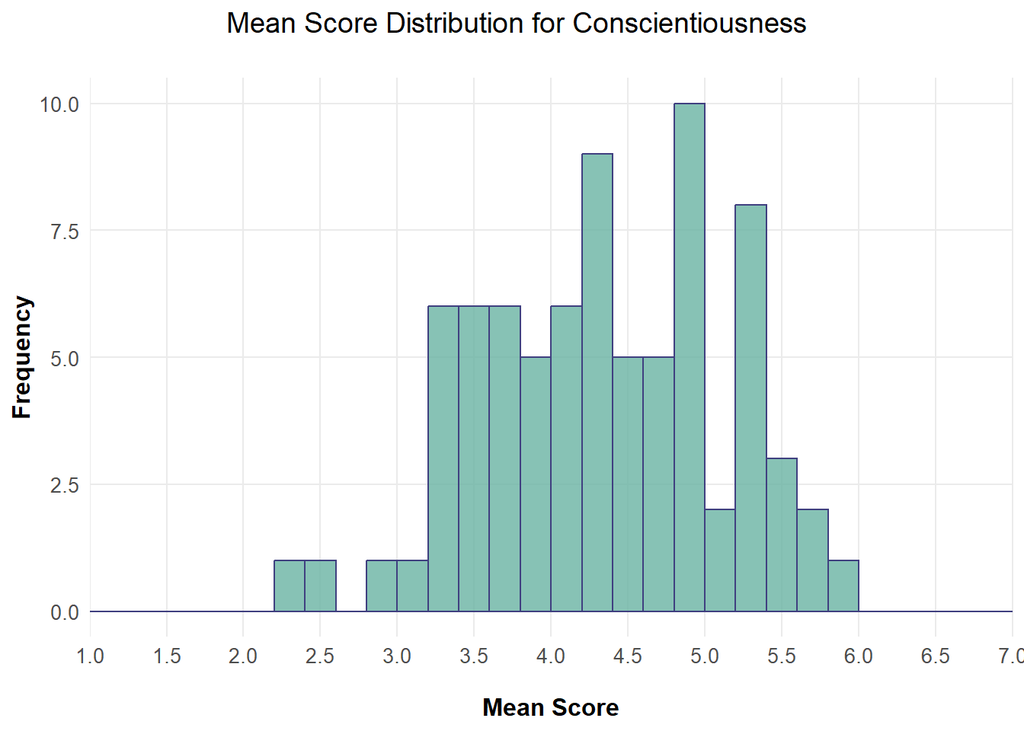

```r
ggplot(data_processed_after_exclusions, aes(x = mean_conscient)) +
  geom_histogram(binwidth = 0.2,
                 boundary = 0,
                 fill = "#69b3a2",
                 color = "#404080",
                 alpha = 0.8) +
  xlab("Mean Score") +
  ylab("Frequency") +
  theme_minimal() +
  scale_x_continuous(breaks = seq(1, 7, 0.5),
                     limits = c(1, 7), expand = c(0, 0)) +
  coord_cartesian(xlim = c(1, 7)) +
  theme(panel.grid.minor = element_blank(),
        axis.title.x = element_text(size = 12, face = "bold", margin = margin(t=15)),
        axis.title.y = element_text(size = 12, face = "bold"),
        axis.text = element_text(size = 10),
        legend.position = "none") +
  ggtitle("Mean Score Distribution for Conscientiousness") +
  theme(plot.title = element_text(hjust = 0.4, size = 14, margin = margin(b = 20)))
```

### Neuroticism

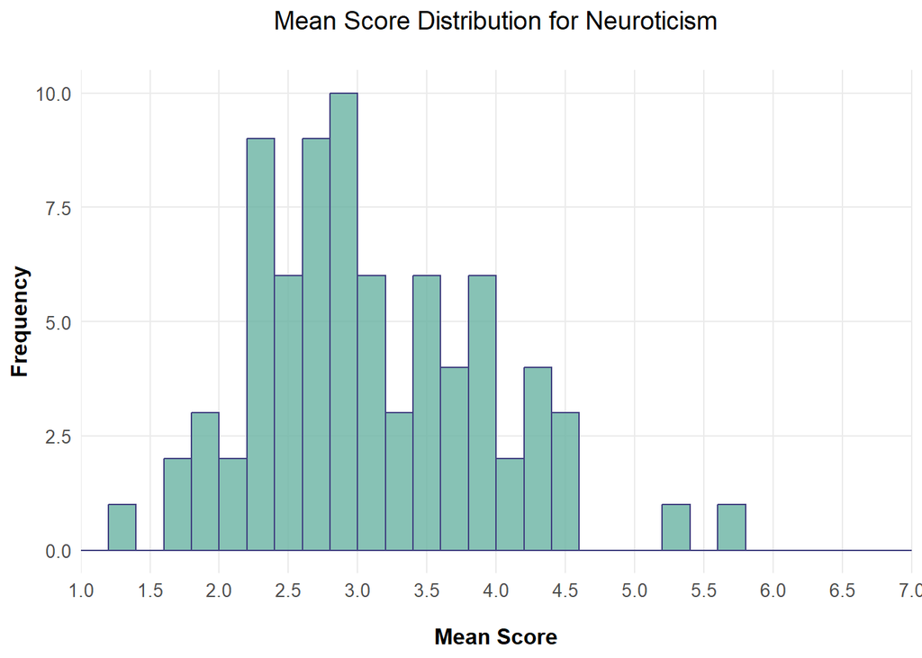

```r
ggplot(data_processed_after_exclusions, aes(x = mean_neuroticism)) +
  geom_histogram(binwidth = 0.2,
                 boundary = 0,
                 fill = "#69b3a2",
                 color = "#404080",
                 alpha = 0.8) +
  xlab("Mean Score") +
  ylab("Frequency") +
  theme_minimal() +
  scale_x_continuous(breaks = seq(1, 7, 0.5),
                     limits = c(1, 7), expand = c(0, 0)) +
  coord_cartesian(xlim = c(1, 7)) +
  theme(panel.grid.minor = element_blank(),
        axis.title.x = element_text(size = 12, face = "bold", margin = margin(t=15)),
        axis.title.y = element_text(size = 12, face = "bold"),
        axis.text = element_text(size = 10),
        legend.position = "none") +
  ggtitle("Mean Score Distribution for Neuroticism") +
  theme(plot.title = element_text(hjust = 0.5, size = 14, margin = margin(b = 20)))
```

### Agreeableness

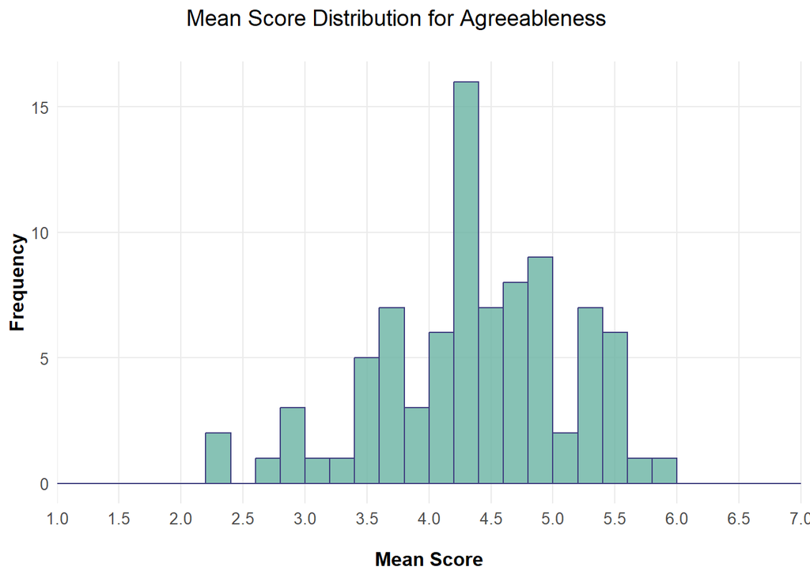

```r
ggplot(data_processed_after_exclusions, aes(x = mean_agreeable)) +
  geom_histogram(binwidth = 0.2,
                 boundary = 0,
                 fill = "#69b3a2",
                 color = "#404080",
                 alpha = 0.8) +
  xlab("Mean Score") +
  ylab("Frequency") +
  theme_minimal() +
  scale_x_continuous(breaks = seq(1, 7, 0.5),
                     limits = c(1, 7), expand = c(0, 0)) +
  coord_cartesian(xlim = c(1, 7)) +
  theme(panel.grid.minor = element_blank(),
        axis.title.x = element_text(size = 12, face = "bold", margin = margin(t=15)),
        axis.title.y = element_text(size = 12, face = "bold"),
        axis.text = element_text(size = 10),
        legend.position = "none") +
  ggtitle("Mean Score Distribution for Agreeableness") +
  theme(plot.title = element_text(hjust = 0.4, size = 14, margin = margin(b = 20)))
```

### Openness

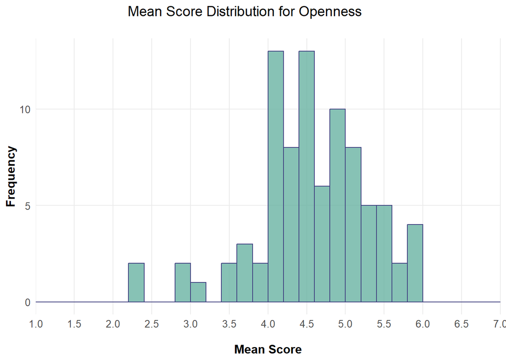

```r
ggplot(data_processed_after_exclusions, aes(x = mean_openness)) +
  geom_histogram(binwidth = 0.2,
                 boundary = 0,
                 fill = "#69b3a2",
                 color = "#404080",
                 alpha = 0.8) +
  xlab("Mean Score") +
  ylab("Frequency") +
  theme_minimal() +
  scale_x_continuous(breaks = seq(1, 7, 0.5),
                     limits = c(1, 7), expand = c(0, 0)) +
  coord_cartesian(xlim = c(1, 7)) +
  theme(panel.grid.minor = element_blank(),
        axis.title.x = element_text(size = 12, face = "bold", margin = margin(t=15)),
        axis.title.y = element_text(size = 12, face = "bold"),
        axis.text = element_text(size = 10),
        legend.position = "none") +
  ggtitle("Mean Score Distribution for Openness") +
  theme(plot.title = element_text(hjust = 0.4, size = 14, margin = margin(b = 20)))
```

## IAT Distribution Histogram

Distribution of the implicit association test is illustrated by the Greenwald D score. The score can range between -2 and +2 indicating the strength and direction of the IAT effect.

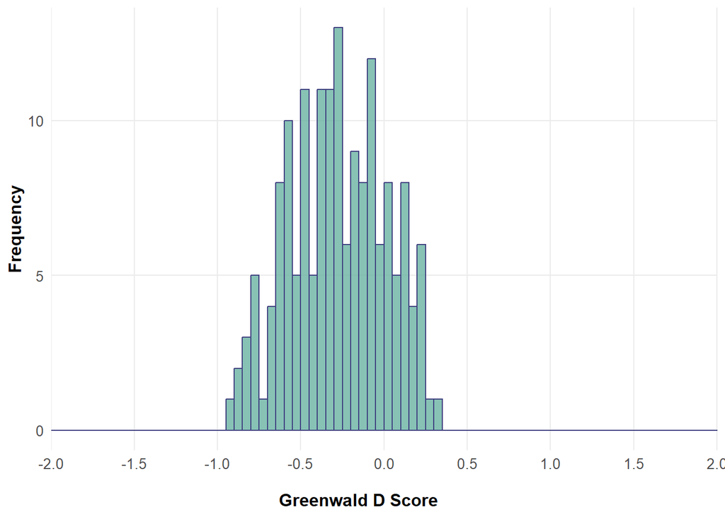

```r
ggplot(data_processed_after_exclusions, aes(x = D)) +
  geom_histogram(binwidth = 0.05,
                 boundary = 0,
                 fill = "#69b3a2",
                 color = "#404080",
                 alpha = 0.8) +
  xlab("Greenwald D Score") +
  ylab("Frequency") +
  theme_minimal() +
  scale_x_continuous(breaks = seq(-2, 2, 0.5),
                     limits = c(-3, 3),
                     expand = c(0, 0)) +
  coord_cartesian(xlim = c(-2, 2)) +
  theme(panel.grid.minor = element_blank(),
        axis.title.x = element_text(size = 12, face = "bold", margin = margin(t=15), hjust = 0.45),
        axis.title.y = element_text(size = 12, face = "bold"),
        axis.text = element_text(size = 10),
        legend.position = "none")
```

# Correlation Table

```r
bfi_iat_corr_matrix <- data_processed_after_exclusions |>
  select(D,
         starts_with("mean_")) |>
  summarise(across(.cols = starts_with("mean_"), #Specifying columns the function is applied to
                .fns = ~ cor(D, ., use = "complete.obs"), #~ defines a function and what it should perform                                                            in this case the correlation between each                                                                  selected mean and D is calculated by column                                                                (represented by the dot). Summarise is applied                                                             to be left with one summarising column for all
                .names = "cor_{.col}"), #naming pattern for the columns
         across(.cols = starts_with("mean_"), #selectts each column that starts with mean
                .fns = ~ cor.test(D, ., #same as above ~ marks the function that is applied. In this case                                           pearson correlation p value is calculated for each selected column
                                  method ="pearson", use = "complete.obs")$p.value,
                .names = "p_value_{.col}")) |> #specifies the names for the resulting columns
  round(2) |> #rounding to two decimal places
  #modify the dataset so it looks better
  pivot_longer(cols = everything(), #select all columns to pivot
               names_to = c(".value", "variable"), #names of the columns after the pivot.
               names_pattern = "(.+)_(.+)") #extracting all of the information that has an _
```

# Hypothesis testing

## Hypothesis 1

A first hypothesis posits a difference between men and women in terms of their mean IAT scores. In order to test whether there are any discrepancies, a t-test is computed. Thereby, the mean values of men and women are being compared and tested for significant difference.

```r
data_h1_testing <- data_processed_after_exclusions |>
   filter(gender %in% c("f", "m"))


#Specify the information within the t test because otherwise it produces a warning.
H1_Result <- t.test(data_h1_testing$D ~ data_h1_testing$gender,data = data_h1_testing)


#Since we are interested in a general difference regardless of direction we put alternative = 'two sided'
report(H1_Result, alternative = "two sided")
```

```
## Effect sizes were labelled following Cohen's (1988) recommendations.
##
## The Welch Two Sample t-test testing the difference of data_h1_testing$D by
## data_h1_testing$gender (mean in group f = -0.25, mean in group m = -0.29)
## suggests that the effect is positive, statistically not significant, and very
## small (difference = 0.04, 95% CI [-0.06, 0.14], t(114.11) = 0.81, p = 0.419;
## Cohen's d = 0.14, 95% CI [-0.20, 0.48])
```

```r
#Different functions of report
report_table(H1_Result)
```

```
## Welch Two Sample t-test
##
## Parameter         |                  Group | Mean_Group1 | Mean_Group2 | Difference |        95% CI | t(114.11) |     p | Cohen's d | Cohen's d  CI
## ---------------------------------------------------------------------------------------------------------------------------------------------------
## data_h1_testing$D | data_h1_testing$gender |       -0.25 |       -0.29 |       0.04 | [-0.06, 0.14] |      0.81 | 0.419 |      0.14 | [-0.20, 0.48]
##
## Alternative hypothesis: two.sided
```

```r
report_effectsize(H1_Result)
```

```
## Effect sizes were labelled following Cohen's (1988) recommendations.
##
## very small (Cohen's d = 0.14, 95% CI [-0.20, 0.48])
```

```r
report_text(H1_Result)
```

```
## Effect sizes were labelled following Cohen's (1988) recommendations.
##
## The Welch Two Sample t-test testing the difference of data_h1_testing$D by
## data_h1_testing$gender (mean in group f = -0.25, mean in group m = -0.29)
## suggests that the effect is positive, statistically not significant, and very
## small (difference = 0.04, 95% CI [-0.06, 0.14], t(114.11) = 0.81, p = 0.419;
## Cohen's d = 0.14, 95% CI [-0.20, 0.48])
```

*Interpretation*: The effect is very small, positive but not statistically significant. Significance is indicated by the p-value, which lies at 0.42, well above the specified value of 0.05 maximum. In addition, the confidence interval indicates a non-significant correlation as well, since it contains 0. Based on our data, it can therefore not be concluded that men and women differ significantly in their IAT mean scores.

## Hypothesis 2:

### Extroversion

```r
Regression_Extroversion <- lm(D ~ mean_extroversion, data= data_processed_after_exclusions)

#Report the results

report(Regression_Extroversion)
```

```
## We fitted a linear model (estimated using OLS) to predict D with
## mean_extroversion (formula: D ~ mean_extroversion). The model explains a
## statistically not significant and very weak proportion of variance (R2 = 0.01,
## F(1, 76) = 1.02, p = 0.316, adj. R2 = 2.53e-04). The model's intercept,
## corresponding to mean_extroversion = 0, is at -0.43 (95% CI [-0.73, -0.14],
## t(76) = -2.92, p = 0.005). Within this model:
##
##   - The effect of mean extroversion is statistically non-significant and positive
## (beta = 0.04, 95% CI [-0.04, 0.11], t(76) = 1.01, p = 0.316; Std. beta = 0.12,
## 95% CI [-0.11, 0.34])
##
## Standardized parameters were obtained by fitting the model on a standardized
## version of the dataset. 95% Confidence Intervals (CIs) and p-values were
## computed using a Wald t-distribution approximation.
```

*Interpretation*: The regression was not significant. Therefore, the Extroversion subscale is unable to predict IAT scores on the basis of the data provided.

### Conscientiousness

```r
Regression_Conscient <- lm(D ~ mean_conscient, data = data_processed_after_exclusions)

#Report the results

report(Regression_Conscient)
```

```
## We fitted a linear model (estimated using OLS) to predict D with mean_conscient
## (formula: D ~ mean_conscient). The model explains a statistically not
## significant and very weak proportion of variance (R2 = 5.18e-03, F(1, 76) =
## 0.40, p = 0.531, adj. R2 = -7.91e-03). The model's intercept, corresponding to
## mean_conscient = 0, is at -0.18 (95% CI [-0.53, 0.18], t(76) = -0.98, p =
## 0.329). Within this model:
##
##   - The effect of mean conscient is statistically non-significant and negative
## (beta = -0.03, 95% CI [-0.11, 0.06], t(76) = -0.63, p = 0.531; Std. beta =
## -0.07, 95% CI [-0.30, 0.16])
##
## Standardized parameters were obtained by fitting the model on a standardized
## version of the dataset. 95% Confidence Intervals (CIs) and p-values were
## computed using a Wald t-distribution approximation.
```

*Interpretation*: The regression was not significant. Therefore, the Conscientiousness subscale is unable to predict IAT scores on the basis of the data provided.

### Neuroticism

```r
Regression_Neuroticism <- lm(D ~ mean_neuroticism, data = data_processed_after_exclusions)

#Report the results

report(Regression_Neuroticism)
```

```
## We fitted a linear model (estimated using OLS) to predict D with
## mean_neuroticism (formula: D ~ mean_neuroticism). The model explains a
## statistically not significant and very weak proportion of variance (R2 =
## 3.69e-03, F(1, 76) = 0.28, p = 0.597, adj. R2 = -9.42e-03). The model's
## intercept, corresponding to mean_neuroticism = 0, is at -0.35 (95% CI [-0.59,
## -0.10], t(76) = -2.84, p = 0.006). Within this model:
##
##   - The effect of mean neuroticism is statistically non-significant and positive
## (beta = 0.02, 95% CI [-0.06, 0.10], t(76) = 0.53, p = 0.597; Std. beta = 0.06,
## 95% CI [-0.17, 0.29])
##
## Standardized parameters were obtained by fitting the model on a standardized
## version of the dataset. 95% Confidence Intervals (CIs) and p-values were
## computed using a Wald t-distribution approximation.
```

*Interpreation*: The regression was not significant. Therefore, the Neuroticism subscale is unable to predict IAT scores on the basis of the data provided.

### Agreeableness

```r
Regression_Agreeable <- lm(D ~ mean_agreeable, data= data_processed_after_exclusions)

#Report the results

report(Regression_Agreeable)
```

```
## We fitted a linear model (estimated using OLS) to predict D with mean_agreeable
## (formula: D ~ mean_agreeable). The model explains a statistically not
## significant and very weak proportion of variance (R2 = 2.63e-03, F(1, 84) =
## 0.22, p = 0.639, adj. R2 = -9.25e-03). The model's intercept, corresponding to
## mean_agreeable = 0, is at -0.18 (95% CI [-0.55, 0.19], t(84) = -0.96, p =
## 0.340). Within this model:
##
##   - The effect of mean agreeable is statistically non-significant and negative
## (beta = -0.02, 95% CI [-0.10, 0.06], t(84) = -0.47, p = 0.639; Std. beta =
## -0.05, 95% CI [-0.27, 0.17])
##
## Standardized parameters were obtained by fitting the model on a standardized
## version of the dataset. 95% Confidence Intervals (CIs) and p-values were
## computed using a Wald t-distribution approximation.
```

*Interpretation*: The regression was not significant. Therefore, the Agreeableness subscale is unable to predict IAT scores on the basis of the data provided.

### Openness

```r
Regression_Openness <- lm(D ~ mean_openness, data = data_processed_after_exclusions)

#Report the results

report(Regression_Openness)
```

```
## We fitted a linear model (estimated using OLS) to predict D with mean_openness
## (formula: D ~ mean_openness). The model explains a statistically not
## significant and very weak proportion of variance (R2 = 1.16e-04, F(1, 84) =
## 9.77e-03, p = 0.921, adj. R2 = -0.01). The model's intercept, corresponding to
## mean_openness = 0, is at -0.25 (95% CI [-0.65, 0.16], t(84) = -1.20, p =
## 0.234). Within this model:
##
##   - The effect of mean openness is statistically non-significant and negative
## (beta = -4.35e-03, 95% CI [-0.09, 0.08], t(84) = -0.10, p = 0.921; Std. beta =
## -0.01, 95% CI [-0.23, 0.21])
##
## Standardized parameters were obtained by fitting the model on a standardized
## version of the dataset. 95% Confidence Intervals (CIs) and p-values were
## computed using a Wald t-distribution approximation.
```

*Interpretation*: The regression was not significant. Therefore, the Openness subscale is unable to predict IAT scores on the basis of the data provided.

# Regression Plots

A series of scatter plots with regression line illustrates the extent to which BFI subscales predict IAT scores. The extreme IAT scores, i.e. the 10% top and bottom scores, are illustrated using a triangle. Finally, all five subscales are combined into a single plot.

## Extroversion

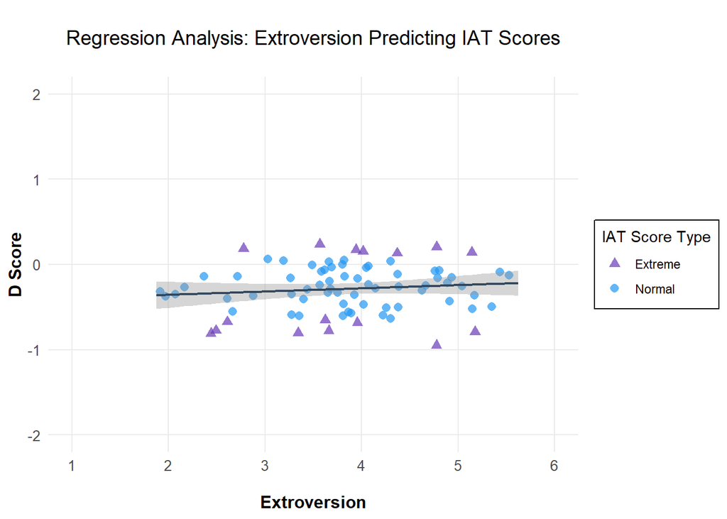

```r
#Create a new variable with extreme 10% top and bottom IAT Scores in order to plot them later
data_extreme_scores <- data_processed_after_exclusions |>
  mutate(extreme_score_IAT = ifelse(D <= quantile(D, 0.1) | D >= quantile(D, 0.9), "Extreme", "Normal"))

#Plot
plot_extroversion <-  ggplot(data_extreme_scores,
                             aes(y = D,
                             x = mean_extroversion,
                             color = extreme_score_IAT)) +
  geom_jitter(aes(shape = extreme_score_IAT), #add different shapes for IAT extreme Scores
              alpha = 0.7,
              width = 0.2,
              size = 2.5) +
  geom_smooth(formula = y ~ x,
              method = "lm",
              color = "#34495e",
              size = 0.8) +
  scale_color_manual(values = c("Normal" = "#2196F3",
                                "Extreme" = "#673AB7"), #values and colors for legend
                     guide = guide_legend(title = "IAT Score Type")) + #title for legend
  scale_shape_manual(values = c("Normal" = 16, "Extreme" = 17),
                     guide = guide_legend(title = "IAT Score Type")) + #shape for legend
  ylab("D Score") +
  xlab("Extroversion") +
  ggtitle("Regression Analysis: Extroversion Predicting IAT Scores") +
  theme_minimal() +
  scale_x_continuous(breaks = seq(1, 6, 1), limits = c(1, 6)) + #breaks and limits for x-axis
  scale_y_continuous(breaks = seq(-2, 2, 1), limits = c(-2, 2)) + #breaks and limits for y-axis
  theme(panel.grid.minor = element_blank(), #plot appearance
        axis.title.x = element_text(size = 12, face = "bold", margin = margin(t=15), hjust = 0.5),
        axis.title.y = element_text(size = 12, face = "bold"),
        axis.text = element_text(size = 10),
        legend.box.background = element_rect(color = "black", size = 0.5),
        plot.title = element_text(hjust = 0.5, size = 14, margin = margin(b = 20, t= 15))) #adjust title position

#Look at plot
plot_extroversion
```

*Interpretation*: As can be seen in the regression calculation above, the effect is not significant, but slightly positive. This can be derived from the diagram, albeit only to a very small extent. The intercept is at -0.43, which also seems to be consistent within the diagram.

## Conscientiousness

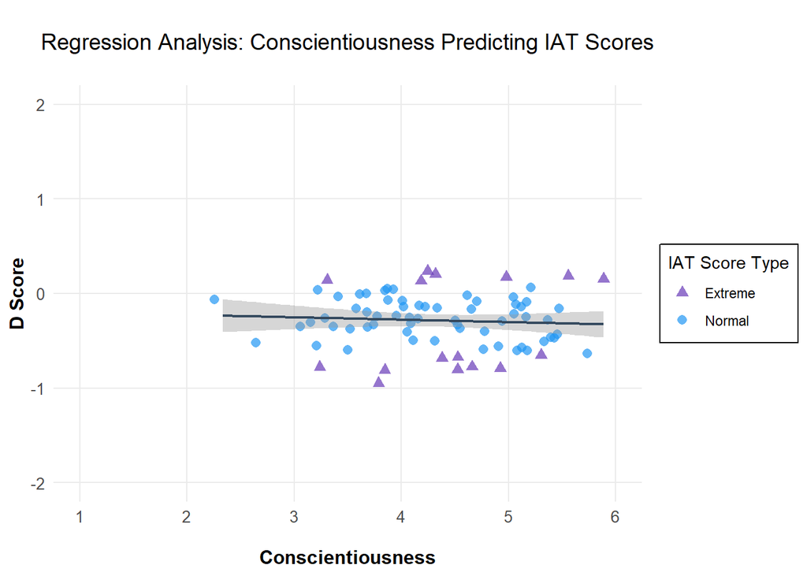

```r
plot_conscient <-  ggplot(data_extreme_scores,
                          aes(y = D,
                             x = mean_conscient,
                             color = extreme_score_IAT)) +
  geom_jitter(aes(shape = extreme_score_IAT),
              alpha = 0.7,
              width = 0.2,
              size = 2.5) +
  geom_smooth(formula = y ~ x,
              method = "lm",
              color = "#34495e",
              size = 0.8) +
  scale_color_manual(values = c("Normal" = "#2196F3",
                                "Extreme" = "#673AB7"),
                     guide = guide_legend(title = "IAT Score Type")) +
  scale_shape_manual(values = c("Normal" = 16, "Extreme" = 17),
                     guide = guide_legend(title = "IAT Score Type")) +
  ylab("D Score") +
  xlab("Conscientiousness") +
  ggtitle("Regression Analysis: Conscientiousness Predicting IAT Scores") +
  theme_minimal() +
  scale_x_continuous(breaks = seq(1, 6, 1), limits = c(1, 6)) +
  scale_y_continuous(breaks = seq(-2, 2, 1), limits = c(-2, 2)) +
  theme(panel.grid.minor = element_blank(),
        axis.title.x = element_text(size = 12, face = "bold", margin = margin(t=15), hjust = 0.5),
        axis.title.y = element_text(size = 12, face = "bold"),
        axis.text = element_text(size = 10),
        legend.box.background = element_rect(color = "black", size = 0.5),
        plot.title = element_text(hjust = 0.5, size = 14, margin = margin(b = 20, t= 15)))

#Look at plot
plot_conscient
```

*Interpretation*: Although the effect is again not significant, it appears to be slightly negative for the Conscientiousness subscale. This seems to be clear from the diagram, but it is very difficult to read. The intercept is -0.18, which also appears to be consistent in the diagram.

## Neuroticism

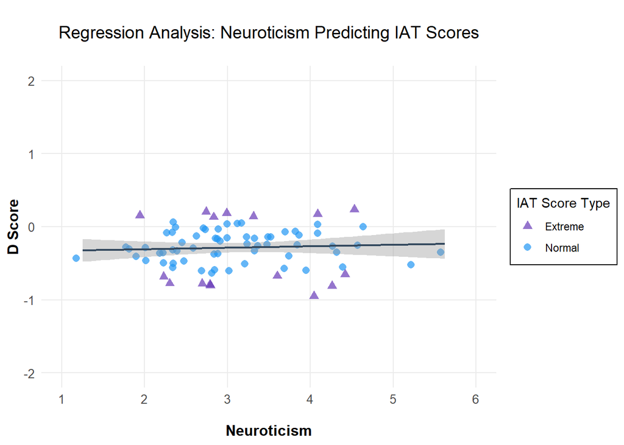

```r
plot_neuroticism <-  ggplot(data_extreme_scores,
                            aes(y = D,
                             x = mean_neuroticism,
                             color = extreme_score_IAT)) +
  geom_jitter(aes(shape = extreme_score_IAT),
              alpha = 0.7,
              width = 0.2,
              size = 2.5) +
  geom_smooth(formula = y ~ x,
              method = "lm",
              color = "#34495e",
              size = 0.8) +
  scale_color_manual(values = c("Normal" = "#2196F3",
                                "Extreme" = "#673AB7"),
                     guide = guide_legend(title = "IAT Score Type")) +
  scale_shape_manual(values = c("Normal" = 16, "Extreme" = 17),
                     guide = guide_legend(title = "IAT Score Type")) +
  ylab("D Score") +
  xlab("Neuroticism") +
  ggtitle("Regression Analysis: Neuroticism Predicting IAT Scores") +
  theme_minimal() +
  scale_x_continuous(breaks = seq(1, 6, 1), limits = c(1, 6)) +
  scale_y_continuous(breaks = seq(-2, 2, 1), limits = c(-2, 2)) +
  theme(panel.grid.minor = element_blank(),
        axis.title.x = element_text(size = 12, face = "bold", margin = margin(t=15), hjust = 0.5),
        axis.title.y = element_text(size = 12, face = "bold"),
        axis.text = element_text(size = 10),
        legend.box.background = element_rect(color = "black", size = 0.5),
        plot.title = element_text(hjust = 0.5, size = 14, margin = margin(b = 20, t = 15)))

#Look at plot
plot_neuroticism
```

*Interpretation*: Again, there appears to be a slightly positive trend in the regression line. However, as seen in the calculation, it is not significant and only has a faint indication. The intercept for neuroticism lies at -0.35, and this appears to be consistent with the graph.

## Agreeableness

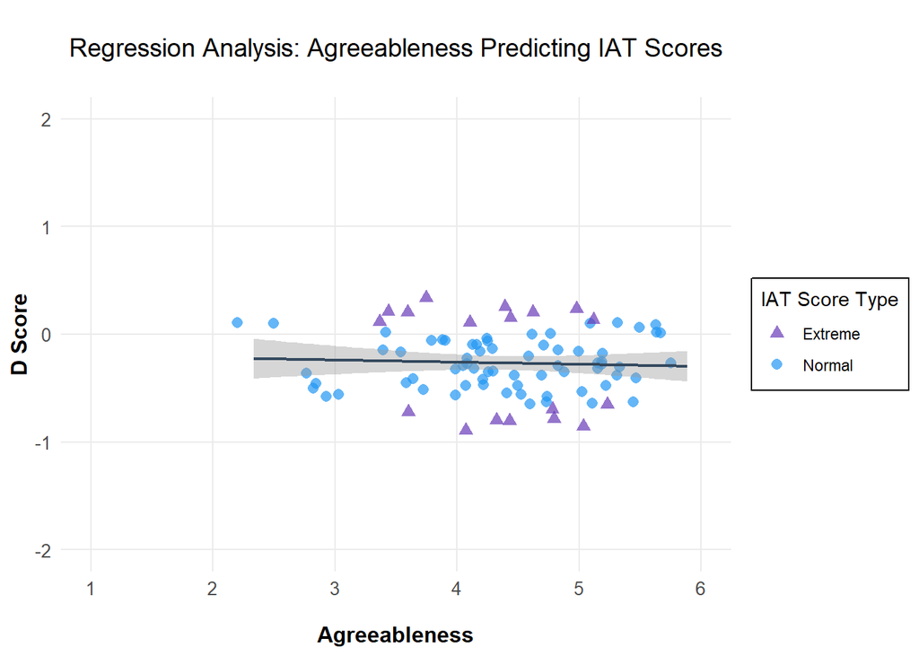

```r
plot_agreeable <-  ggplot(data_extreme_scores,
                          aes(y = D,
                             x = mean_agreeable,
                             color = extreme_score_IAT)) +
  geom_jitter(aes(shape = extreme_score_IAT),
              alpha = 0.7,
              width = 0.2,
              size = 2.5) +
  geom_smooth(formula = y ~ x,
              method = "lm",
              color = "#34495e",
              size = 0.8) +
  scale_color_manual(values = c("Normal" = "#2196F3",
                                "Extreme" = "#673AB7"),
                     guide = guide_legend(title = "IAT Score Type")) +
  scale_shape_manual(values = c("Normal" = 16, "Extreme" = 17),
                     guide = guide_legend(title = "IAT Score Type")) +
  ylab("D Score") +
  xlab("Agreeableness") +
  ggtitle("Regression Analysis: Agreeableness Predicting IAT Scores") +
  theme_minimal() +
  scale_x_continuous(breaks = seq(1, 6, 1), limits = c(1, 6)) +
  scale_y_continuous(breaks = seq(-2, 2, 1), limits = c(-2, 2)) +
  theme(panel.grid.minor = element_blank(),
        axis.title.x = element_text(size = 12, face = "bold", margin = margin(t=15), hjust = 0.5),
        axis.title.y = element_text(size = 12, face = "bold"),
        axis.text = element_text(size = 10),
        legend.box.background = element_rect(color = "black", size = 0.5),
        plot.title = element_text(hjust = 0.5, size = 14, margin = margin(b = 20, t = 15)))

#Look at plot
plot_agreeable
```

*Interpretation*: The graph shows the slightly negative calculated regression. The intercept value is -0.18. The graph and the calculated regression seem to match in this case as well.

## Openness

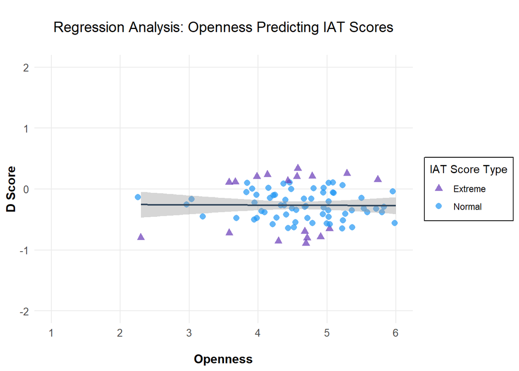

```r
plot_openness <-  ggplot(data_extreme_scores,
                             aes(y = D,
                             x = mean_openness,
                             color = extreme_score_IAT)) +
  geom_jitter(aes(shape = extreme_score_IAT), #add different shapes for IAT extreme Scores
              alpha = 0.7,
              width = 0.2,
              size = 2.5) +
  geom_smooth(formula = y ~ x,
              method = "lm",
              color = "#34495e",
              size = 0.8) +
  scale_color_manual(values = c("Normal" = "#2196F3",
                                "Extreme" = "#673AB7"), #values and colors for legend
                     guide = guide_legend(title = "IAT Score Type")) + #title for legend
  scale_shape_manual(values = c("Normal" = 16, "Extreme" = 17),
                     guide = guide_legend(title = "IAT Score Type")) + #shape for legend
  ylab("D Score") +
  xlab("Openness") +
  ggtitle("Regression Analysis: Openness Predicting IAT Scores") +
  theme_minimal() +
  scale_x_continuous(breaks = seq(1, 6, 1), limits = c(1, 6)) + #breaks and limits for x-axis
  scale_y_continuous(breaks = seq(-2, 2, 1), limits = c(-2, 2)) + #breaks and limits for y-axis
  theme(panel.grid.minor = element_blank(), #plot appearance
        axis.title.x = element_text(size = 12, face = "bold", margin = margin(t=15), hjust = 0.5),
        axis.title.y = element_text(size = 12, face = "bold"),
        axis.text = element_text(size = 10),
        legend.box.background = element_rect(color = "black", size = 0.5),
        plot.title = element_text(hjust = 0.5, size = 14, margin = margin(b = 20, t = 15)))

#Look at plot
plot_openness
```

*Interpretation*: Finally, the openness is also consistent with the calculated data. Although nowhere significant, the intercept of -0.25 seems to be approximately reproduced. A negative trend would be expected, which seems impossible to interpret from this diagram.

## Combined Plot

[figure not shown]

```r
#Remove all legends and titles

final_plot_extroversion <- plot_extroversion + theme(legend.position = "none") + labs(title = "")
final_plot_conscient <- plot_conscient + theme(legend.position = "none")  + labs(title = "")
final_plot_neuroticism <- plot_neuroticism + theme(legend.position = "none")  + labs(title = "")
final_plot_agreeable <- plot_agreeable + theme(legend.position = "none")  + labs(title = "")
final_plot_openness <- plot_openness + theme(legend.position = "none") + labs(title = "")

# Combine the plots and add the title
combined_plot <- plot_grid(final_plot_extroversion,
                           final_plot_agreeable,
                           final_plot_conscient,
                           final_plot_neuroticism,
                           final_plot_openness,
                           ncol = 3,
                           align = "v",
                           axis = "l",
                           labels = c("", "", "", "", "")) +
  ggtitle("Regression Analysis: BFI Subscale Scores Predicting IAT Scores") +
  theme(strip.background = element_blank(),  # Remove strip labels
        plot.title = element_text(hjust = 0.5,
                                  size = 16,
                                  margin = margin(b = 20,
                                                  t = 10,
                                                  unit = "pt")),  # Adjust margin for the title
        plot.margin = margin(40, 40, 40, 40),
        panel.background = element_rect(fill = "white", color = "white"))

# Show the plot
print(combined_plot)
```

## Saving plots

```r
ggsave(filename = "combined_plot_Final_Assignment.png", plot = combined_plot, path = "../communications", width = 12, height = 8, bg = "white") #Set the background for the title as otherwise it goes black

ggsave(filename = "combined_plot_Final_Assignment.pdf", plot = combined_plot, path = "../communications", width = 12, height = 8)
```